# Tutorial 3: Debugging Concurrent C++ Programs

Now that assignment 1 is out, it is a good time to introduce C++ best practices and debugging tools. In this handout, you will learn

- How to protect resources with C++ smart pointers
- The pitfalls of using smart pointers incorrectly
- How to use tooling to detect data races and memory leaks

# 1 Protecting Shared Resources

Even if you don’t manually manage memory with `new` and `delete` (you shouldn’t), you may depend on an API that returns owned resources. For example, the Unix API often requires that you `close(resource)` after using them.

C++ provides `std::unique_ptr` to protect such resources automatically using RAII. For example:

Godbolt link **|** Fsmbolt link

**Code example**

```cpp
int main()
{
    // int* foo = new int { 0 };
    std::unique_ptr<int> foo = std::make_unique<int>(0);

    // FILE* bar = fopen("file.txt", "w");
    auto deleter = [](FILE* f) {
    	fclose(f);
    };

    auto bar = std::unique_ptr<FILE, decltype(deleter)> {
    	fopen("file.txt", "w"), deleter
    };

    use_foo(foo.get());
    use_bar(bar.get());
} // bar and foo deleted here
```

Snippet 1: Protecting resources with std::unique_ptr

However, things quickly become complicated with shared resources. Consider the following scenario:

Godbolt link **|** Fsmbolt link

**Code example**

```cpp
void reader(int* foo)
{
    std::cout << *foo;
    delete foo;
}

void writer(int* foo)
{
    (*foo)++;
    delete foo;
}

void schedule_unsafe()
{
    int* foo = new int;

    std::thread { reader, foo }.detach();
    std::thread { writer, foo }.detach();
}
```

Snippet 2: Sharing resources without protection

There are multiple problems here:

- We have no way of tracking who is (not) using the resource. Thus, we have no way of knowing when to free the resource.
- Each function may believe that it is responsible for deleting the resource, since it is hard to know whether `int*` is an owned or non-owning pointer.

## 1.1 What if I don’t protect them?

In languages like Python, Java, and JavaScript, memory safety is enforced at runtime by *fail-stopping*. Thus, we can reason with programs that either run correctly or crash.

C++ however specifies that invalid access patterns result in *undefined behaviour*. Such memory safety issues account for [70% of security vulnerabilities](https://www.nsa.gov/Press-Room/News-Highlights/Article/Article/3215760/nsa-releases-guidance-on-how-to-protect-against-software-memory-safety-issues/). Even if the program is an internal service, other internal users have to account for *byzantine failure* for correctness and reliability.

Your task: Besides data races, what other undefined behaviours can you find?

**Code example**

```cpp
void reader(int* foo)
{
    std::cout << *foo;
    delete foo;
}

void writer(int* foo)
{
    (*foo)++;
    delete foo;
}

void schedule_unsafe()
{
    int* foo = new int;

    std::thread { reader, foo }.detach();
    std::thread { writer, foo }.detach();
}
```

Snippet 3: Problems with shared lifetime

**Answer**

1. Double free - both the reader and writer `delete foo` without knowing if the other has done so.
2. Use after free - the writer/reader may `delete foo` before reader/writer accesses it.
3. Uninitialised variable - `new int` does not initialise `foo` with any value.

## 1.2 How AddressSanitizer can help you

How can tooling help us? Let’s compile and run with `clang++ -std=c++20 -g -fsanitize=address main.cpp`. The output here has been *sanitised* for sanity, stripping out the unnecessary parts of the stack trace and cleaning up the C++ function signatures.

**AddressSanitizer Output**

```
=================================================================
==39903==ERROR: AddressSanitizer: heap-use-after-free on address 0x602000000010
  at pc 0x5600620a8209 bp 0x7f69578fdd20 sp 0x7f69578fdd18
READ of size 4 at 0x602000000010 thread T2
    #0 0x5600620a8208 in writer(int*)
    (truncated)

0x602000000010 is located 0 bytes inside of 4-byte region [0x602000000010,0x602000000014)
freed by thread T1 here:
    #0 0x5600620a5d0a in operator delete(void*)
    (truncated)

SUMMARY: AddressSanitizer: heap-use-after-free in writer(int*)
    (truncated)

=================================================================
==39903==ERROR: AddressSanitizer: attempting double-free on 0x602000000010 in thread T2:
    #0 0x5600620a5d0a in operator delete(void*)
    (truncated)

freed by thread T1 here:
    #0 0x5600620a5d0a in operator delete(void*)
    (truncated)

SUMMARY: AddressSanitizer: double-free in operator delete(void*)
    (truncated)
```

**Extra**

- Use of uninitialised memory can be detected with `-fsanitize=memory`.
- If you would like to see all errors, compile with `clang++ -std=c++20 -g -fsanitize=address -fsanitize-recover=address -o exe main.cpp` and run with `ASAN_OPTIONS=halt_on_error=0 ./exe`.

# 2 Protecting resources with shared lifetimes

Fortunately, this is a common enough problem that the C++ standard library comes with a facility to solve exactly this problem — `std::shared_ptr`. It is a *reference-counted smart pointer* that allows safely sharing resources.

## 2.1 Reference counting

In order to understand how `std::shared_ptr` works and how to use it, we must first understand the core principle of its operation, which is reference counting.

The idea is that each instance of the shared pointer is a *reference* to the pointed-to data. When you copy a shared pointer, the number of references increases by 1. When an instance is destructed, the number of references decreases by 1.

Thus, when the number of references reaches 0, the `std::shared_ptr` automatically calls the destructor on the object that it is pointing to, essentially solving for us the problem of knowing when the last user of a resource has finished using it.

Let’s look at the example below. Conveniently, `std::shared_ptr` has a `use_count` method that tells us how many references there are to the managed object, which we can use to inspect the state.

Godbolt link **|** Fsmbolt link

**Reference counting example**

```cpp
void rc(const char* s, const std::shared_ptr<int>& x)
{
    auto refs = x.use_count();
    printf("%s: %zu ref%s\n", s, refs, refs == 1 ? "" : "s");
}

void foo(std::shared_ptr<int> arg)  // num refs: 5
{
    rc("foo 1", arg);
    auto z = arg;   // num refs: 6
    rc("foo 2", arg);

} // num refs: 4 (`arg` & `z` are gone)

int main()
{
    auto x = std::make_shared<int>(100);
    rc("initial", x);

    {
    	auto a = x;     rc("A", x); // 2
    	auto b = x;     rc("B", x); // 3
    	auto c = a;     rc("C", x); // 4
    	foo(x);         rc("D", x); // 4
    }

    rc("E", x); // 1 (all the above are gone)

} // num refs: 0, destructor called
```

## 2.2 Using `std::shared_ptr`

Now that we understand the basics of `std::shared_ptr`, let’s try to use it to fix up our example with shared resources. Unfortunately, if we run our implementation below, we find that there are still problems! In particular, we still have data races. How is that possible?

Godbolt link **|** Fsmbolt link

**Code example**

```cpp
void reader2(std::shared_ptr<int> foo)
{
    std::cout << *foo;
}

void writer2(std::shared_ptr<int> foo)
{
    (*foo)++;
}

void schedule_safe()
{
    std::shared_ptr<int> foo { std::make_shared<int>(0) };

    std::thread { reader2, foo }.detach();
    std::thread { writer2, foo }.detach();
}
```

Snippet 4: Using `std::shared_ptr` to protect shared resources

## 2.3 Using `std::shared_ptr` *correctly*

In order to understand why we still have data races, it is important to know this:

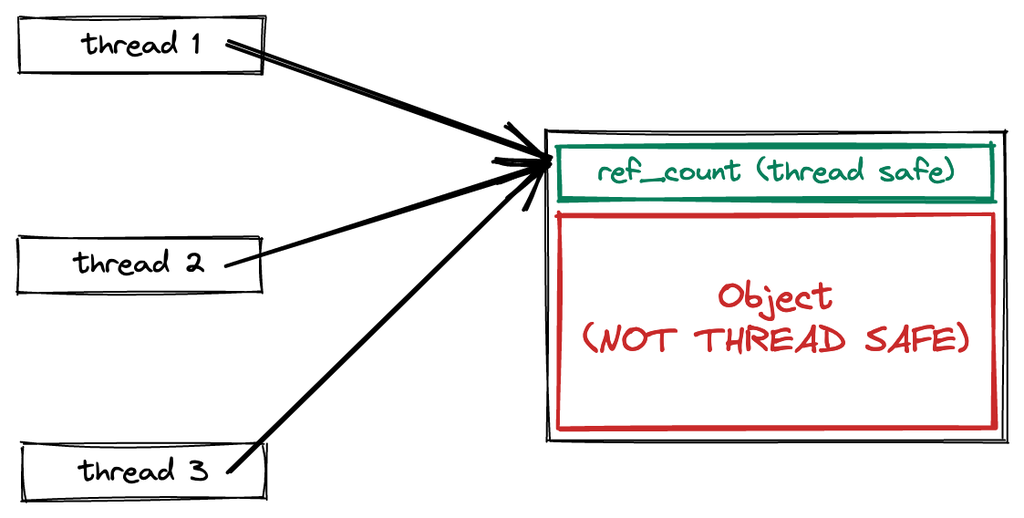

Thread safety of `std::shared_ptr` only applies to the reference count!

In the example above, we are free to make and destroy copies from multiple threads, because these operations only affect the reference count, which *is* thread-safe.

Unfortunately, the object itself — in this case, our `int` — is *not* thread-safe, leading to a data race: the reader thread reads (`*foo`) while the writer thread increments (`(*foo)++`).

This is one of the most common mistakes when using `std::shared_ptr`.

## 2.4 ThreadSanitizer and common `std::shared_ptr` mistakes

Apart from the common mistake above, there are a number of other ways that `std::shared_ptr` can be misused; we have a few examples below.

Your task: With the help of ThreadSanitizer, figure out what is wrong with these examples.

### 2.4.1 Example 1

Godbolt link **|** Fsmbolt link

**Code example**

```cpp
int main()
{
    std::shared_ptr<int> ptr = std::make_shared<int>(0);

    auto reader = std::thread([](std::shared_ptr<int> ptr) {
    	for(int i = 0; i < 100; i++)
    		printf("%d ", *ptr);
    	printf("\n");
    }, ptr);

    auto writer = std::thread([](std::shared_ptr<int> ptr) {
    	for(int i = 0; i < 100; i++)
    		*ptr = i;
    }, ptr);

    reader.join();
    writer.join();
}
```

**Answer**

This is the same problem as we just discussed above, which is unsynchronised access to the managed object itself *through* the shared pointer.

One solution would be to protect resources in a container with a `std::mutex`, or wrap them with `std::atomic`.

**Sample TSan output**

```
==================
WARNING: ThreadSanitizer: data race (pid=48593)
  Write of size 4 at 0x7b0800000030 by thread T2:
    #0 func2()::$_3::operator()(std::shared_ptr<int>) const
    (truncated)

  Previous read of size 4 at 0x7b0800000030 by thread T1:
    #0 func2()::$_2::operator()(std::shared_ptr<int>) const
    (truncated)

SUMMARY: ThreadSanitizer: data race in func2()::$_3::operator()(std::shared_ptr<int>) const
    (truncated)
==================
ThreadSanitizer: reported 1 warnings
```

### 2.4.2 Example 2

Godbolt link **|** Fsmbolt link

**Code example**

```cpp
int main()
{
    std::shared_ptr<int> ptr;

    auto reader = std::thread([](std::shared_ptr<int>& ptr) {
    	while(ptr == nullptr)
    		;
    	printf("%d\n", *ptr);

    }, std::ref(ptr));

    auto writer = std::thread([](std::shared_ptr<int>& ptr) {
    	for(int i = 0; i < 100; i++)
    		ptr = std::make_shared<int>(i);

    }, std::ref(ptr));

    reader.join();
    writer.join();
}
```

**Answer**

Data race on `ptr`. Writer overwrites the reference to `ptr`, which `delete`s the old value and makes a new one. However, the reader may still be using the old value in `*ptr` for printing, even after it was freed.

A better solution would be for each thread to own `ptr` separately by copying into the respective threads.

**Sample TSan output**

```
==================
WARNING: ThreadSanitizer: data race (pid=48675)
  Write of size 8 at 0x7ffc4917a598 by thread T2:
    (truncated)
    #3 std::shared_ptr<int>::operator=(std::shared_ptr<int>&&)
    (truncated)

  Previous read of size 8 at 0x7ffc4917a598 by thread T1:
    (truncated)
    #1 bool std::operator==<int>(std::shared_ptr<int> const&, std::nullptr_t)
    (truncated)

  Location is stack of main thread.

  Location is global '??' at 0x7ffc4915c000 ([stack]+0x1e598)

SUMMARY: ThreadSanitizer: data race in std::enable_if<__and_<std::__not_<
  std::__is_tuple_like<int*>>, std::is_move_constructible<int*>,
  std::is_move_assignable<int*>>::value, void>::type
  std::swap<int*>(int*&, int*&)
==================
==================
WARNING: ThreadSanitizer: data race (pid=48675)
  Read of size 4 at 0x7b0800002030 by thread T1:
    #0 func1()::$_0::operator()(std::shared_ptr<int>&) const
    (truncated)

  Previous write of size 8 at 0x7b0800002030 by thread T2:
    (truncated)
    #9 func1()::$_1::operator()(std::shared_ptr<int>&) const
    (truncated)

  Location is heap block of size 24 at 0x7b0800002020 allocated by thread T2:
    (truncated)

SUMMARY: ThreadSanitizer: data race in
  func1()::$_0::operator()(std::shared_ptr<int>&) const
==================
ThreadSanitizer: reported 2 warnings
```

### 2.4.3 Example 3

**Code example**

```cpp
// Doubly Linked List
struct DLLNode
{
    std::shared_ptr<DLLNode> prev;
    std::shared_ptr<DLLNode> next;
};

struct DLL
{
    std::shared_ptr<DLLNode> head {};
    std::shared_ptr<DLLNode> tail {};

    void push_front(std::shared_ptr<DLLNode>);
    void push_back(std::shared_ptr<DLLNode>);

    std::shared_ptr<DLLNode> front();
    std::shared_ptr<DLLNode> back();
};
```

**Answer**

Unfortunately, ThreadSanitizer cannot save us here! This is a problematic use of `std::shared_ptr`, even on a single thread; we get a memory leak due to a circular reference. Fortunately, our old friend AddressSanitizer can detect leaks as well!

(LeakSanitizer is the real hero, but it is integrated into ASan on Clang)

Godbolt link **|** Fsmbolt link

For adjacent nodes in our doubly-linked list, the first node’s `next` points at the second node, while the second node’s `prev` points at the first – this creates a reference cycle, meaning that neither `shared_ptr`’s reference count ever reaches 0.

One solution would be to use `DLLNode* prev`, which does not affect the reference count of shared pointers, but keep the `next` pointer as a shared pointer. This way, all owning references are forward pointing and do not form a cycle.

# 3 Making our own `std::shared_ptr`

Now that we know how to use (and not to use) `std::shared_ptr`, what better exercise than to create our own version?

## 3.1 Initial Attempt

Your task: Write the synchronised implementation in the TODO areas.

Godbolt link **|** Fsmbolt link

```cpp
template <typename T>
struct SharedPtr
{
private:
    size_t m_count;
    T* m_ptr;

    // TODO: add additional fields

public:
    SharedPtr(T* ptr) : m_count(1), m_ptr(ptr)
    {
    }

    SharedPtr(const SharedPtr& other) : m_count(other.m_count), m_ptr(other.m_ptr)
    {
    	// TODO: synchronise this
    	++m_count;
    }

    ~SharedPtr()
    {
    	// TODO: synchronise this
    	if((--m_count) == 0)
    		delete m_ptr;
    }

    // shouldn't need to worry about this
    T* get() { return m_ptr; }
    const T* get() const { return m_ptr; }
};
```

We will explore some incorrect attempts in the following sections.

## 3.2 Attempt #1: Shared count

The first obvious problem is that each pointer has its own `m_count`! This means that the reference count will never reach 0, since they do not actually *share* the reference count.

An obvious fix would be to make the reference count shared, by making it a pointer:

Godbolt link **|** Fsmbolt link

```cpp
template <typename T>
struct SharedPtr1
{
private:
    size_t* m_count;
    T* m_ptr;

    // TODO: add additional fields

public:
    SharedPtr1(T* ptr) : m_count(new size_t(1)), m_ptr(ptr)
    {
    }

    SharedPtr1(const SharedPtr1& other) : m_count(other.m_count), m_ptr(other.m_ptr)
    {
    	++(*m_count);
    }

    ~SharedPtr1()
    {
    	if(--(*m_count) == 0)
    	{
    		delete m_ptr;
    		delete m_count;
    	}
    }

    // shouldn't need to worry about this
    T* get() { return m_ptr; }
    const T* get() const { return m_ptr; }
};
```

Of course, we still get data races, because we still have unsynchronised accesses to the reference count!

## 3.3 Attempt #2: Synchronised reference counting

Now, we can try to use a `std::mutex` to synchronise accesses to the shared reference count. Of course, take note that the mutex itself must also be shared, since all instances of the pointer need to use the *same* mutex.

Godbolt link **|** Fsmbolt link

```cpp
template <typename T>
struct SharedPtr2
{
private:
    size_t* m_count;
    std::mutex* m_mutex;
    T* m_ptr;

public:
    SharedPtr2(T* ptr) : m_count(new size_t(1)), m_mutex(new std::mutex()), m_ptr(ptr)
    {
    }

    SharedPtr2(const SharedPtr2& other) : m_count(other.m_count), m_mutex(other.m_mutex), m_ptr(other.m_ptr)
    {
    	auto lk = std::unique_lock { *m_mutex };
    	++(*m_count);
    }

    ~SharedPtr2()
    {
    	auto lk = std::unique_lock { *m_mutex };
    	if(--(*m_count) == 0)
    	{
    		delete m_ptr;
    		delete m_mutex;
    		delete m_count;
    	}
    }

    // shouldn't need to worry about this
    T* get() { return m_ptr; }
    const T* get() const { return m_ptr; }
};
```

However, we still have a problem. What is it?

**Answer**

Notice that we `delete m_mutex` while it is locked! The guard unlocking it at the end of the destructor will thus be using `m_mutex` after it has been freed. In fact, ThreadSanitizer tells us about this error.

To unlock the mutex safely, we should only delete it after it has been unlocked.

## 3.4 Final attempt

Now, we have all the parts to correctly implement the shared pointer:

Godbolt link **|** Fsmbolt link

```cpp
template <typename T>
struct SharedPtr3
{
private:
    size_t* m_count;
    std::mutex* m_mutex;
    T* m_ptr;

public:
    SharedPtr3(T* ptr) : m_count(new size_t(1)), m_mutex(new std::mutex()), m_ptr(ptr)
    {
    }

    SharedPtr3(const SharedPtr3& other) : m_count(other.m_count), m_mutex(other.m_mutex), m_ptr(other.m_ptr)
    {
    	auto lk = std::unique_lock { *m_mutex };
    	++(*m_count);
    }

    ~SharedPtr3()
    {
    	size_t new_count = 0;
    	{
    		auto lk = std::unique_lock { *m_mutex };
    		new_count = --(*m_count);
    	}

    	/*
    		alternatively, for fancy C++ people:

    		size_t new_count = [this]() {
    			auto lk = std::unique_lock { *m_mutex };
    			return --(*m_count);
    		}();
    	*/

    	if(new_count == 0)
    	{
    		delete m_ptr;
    		delete m_mutex;
    		delete m_count;
    	}
    }

    // shouldn't need to worry about this
    T* get() { return m_ptr; }
    const T* get() const { return m_ptr; }
};
```

If we did everything correctly (and we did!) there should be no more complaints from ThreadSanitizer.

## 3.5 Bonus attempt: Atomics

Instead of using locks, we can also use atomics to achieve the same result! We simply make the reference count atomic, taking care to ensure that we *share* that atomic across all instances of the shared pointer.

That is, we should have a *pointer to an atomic*, **not** an atomic pointer!

Your task: Try implementing `SharedPtr` using atomics instead of mutexes.

Godbolt link **|** Fsmbolt link

**Answer**

```cpp
template <typename T>
struct SharedPtr4
{
private:
    std::atomic<size_t>* m_count;
    T* m_ptr;

public:
    SharedPtr4(T* ptr) : m_count(new std::atomic<size_t>(1)), m_ptr(ptr)
    {
    }

    SharedPtr4(const SharedPtr4& other) : m_count(other.m_count), m_ptr(other.m_ptr)
    {
    	m_count->fetch_add(1);
    }

    ~SharedPtr4()
    {
    	size_t old_count = m_count->fetch_sub(1);
    	if(old_count == 1)
    	{
    		delete m_ptr;
    		delete m_count;
    	}
    }

    // shouldn't need to worry about this
    T* get() { return m_ptr; }
    const T* get() const { return m_ptr; }
};
```

## 3.6 Extra: Overhead of `std::shared_ptr`

Many default to `std::shared_ptr` due to the flexibility of using it as a `std::unique_ptr`. However, this encourages several anti-patterns:

1. **Ambiguous Ownership**  
   Most resources should have a single owner using `std::unique_ptr`, borrowing references from a main thread with raw pointers. For example, you can consider rearchitecting to use Singleton pattern or Entity Component System pattern.
2. **Memory Leaks**  
   Premature sharing of ownership can result in unintended cyclic references, which causes memory leaks. `std::unique_ptr` will never have this issue, since can only ever have one owner.
3. **Performance Overhead**  
   Maintaining reference counts can result in unnecessary synchronisation. Similarly, initialising memory on the heap instead of on the stack can unnecessarily slow down the program and reduce cache locality.

# 4 How `valgrind` can help you

As compared to sanitisers, `valgrind` is slower but offers more details on resource usage such as memory, CPU and syscalls. First compile without `-fsanitize`, otherwise your program may run out of memory. Then, run the executable with `valgrind ./exe` to see the amount of memory leaked:

```
==6791== HEAP SUMMARY:
==6791==     in use at exit: 44 bytes in 2 blocks
==6791==   total heap usage: 9 allocs, 7 frees, 73,404 bytes allocated
==6791==
==6791== LEAK SUMMARY:
==6791==    definitely lost: 44 bytes in 2 blocks
==6791==    indirectly lost: 0 bytes in 0 blocks
==6791==      possibly lost: 0 bytes in 0 blocks
==6791==    still reachable: 0 bytes in 0 blocks
==6791==         suppressed: 0 bytes in 0 blocks
==6791== Rerun with --leak-check=full to see details of leaked memory
```

Re-running with `--leak-check=full`, it tells us where memory has been allocated and where it has been lost (not deleted).

```
==6860== HEAP SUMMARY:
==6860==     in use at exit: 44 bytes in 2 blocks
==6860==   total heap usage: 9 allocs, 7 frees, 73,404 bytes allocated
==6860==
==6860== 4 bytes in 1 blocks are definitely lost in loss record 1 of 2
==6860==    at 0x4843003: operator new(unsigned long) (vg_replace_malloc.c:422)
==6860==    by 0x10A2D9: main (shared_ptr.cpp:33)
==6860==
==6860== 40 bytes in 1 blocks are definitely lost in loss record 2 of 2
==6860==    at 0x4843003: operator new(unsigned long) (vg_replace_malloc.c:422)
==6860==    by 0x10AFA1: SharedPtr<int>::SharedPtr(int*) (shared_ptr.cpp:12)
==6860==    by 0x10A2F4: main (shared_ptr.cpp:33)
==6860==
==6860== LEAK SUMMARY:
==6860==    definitely lost: 44 bytes in 2 blocks
==6860==    indirectly lost: 0 bytes in 0 blocks
==6860==      possibly lost: 0 bytes in 0 blocks
==6860==    still reachable: 0 bytes in 0 blocks
==6860==         suppressed: 0 bytes in 0 blocks
==6860==
==6860== For lists of detected and suppressed errors, rerun with: -s
==6860== ERROR SUMMARY: 2 errors from 2 contexts (suppressed: 0 from 0)
```

© CS3211 Teaching Team, All Rights Reserved

^